# Help A. G.

This document produces simulated data set similar to what A. G. has and runs the regressions covered in the TA session.

# Data

## Table

First, we create some simulated data for two machines with sales for 5 years.

```r
set.seed(20150331)
d <- data.frame(year = rep(2010:2014, each = 2), machine = factor(rep(c('EPIC', 'MP'), 5), levels = c('EPIC', 'MP')), sales = rnorm(10, 10000, 100))

## Manually make it so EPIC machine has higher sales and much higher after
## intervention
d$sales[d$machine == 'EPIC' & d$year < 2012] <- rnorm(2, 40000, 200)
d$sales[d$machine == 'EPIC' & d$year >= 2012] <- rnorm(3, 60000, 300)
d$intervention <- ifelse(d$year < 2012, 0, 1)

## Center year
d$yearCen <- d$year - 2010
knitr::kable(d, format = 'html', digits = 2)
```

| year | machine | sales | intervention | yearCen |
| --- | --- | --- | --- | --- |
| 2010 | EPIC | 40059.77 | 0 | 0 |
| 2010 | MP | 9895.11 | 0 | 0 |
| 2011 | EPIC | 39796.54 | 0 | 1 |
| 2011 | MP | 9996.00 | 0 | 1 |
| 2012 | EPIC | 60460.43 | 1 | 2 |
| 2012 | MP | 9863.60 | 1 | 2 |
| 2013 | EPIC | 59434.50 | 1 | 3 |
| 2013 | MP | 10006.00 | 1 | 3 |
| 2014 | EPIC | 60284.32 | 1 | 4 |
| 2014 | MP | 10028.96 | 1 | 4 |

## Vis

Next, we can visualize it.

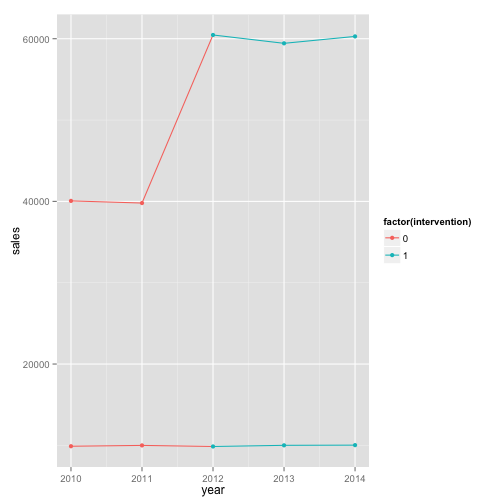

```r
library('ggplot2')
ggplot(data = d, aes(x = year, y = sales, group = machine, colour = factor(intervention))) + geom_line() + geom_point()
```

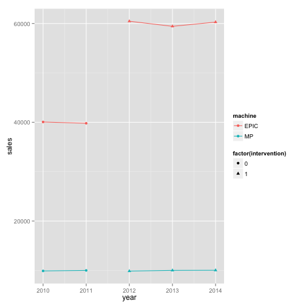

```r
ggplot(data = d, aes(x = year, y = sales, group = paste0(machine, intervention), colour = machine, shape = factor(intervention))) + geom_line() + geom_point()
```

# Regression

## Interaction

Using the EPIC machine as the reference group, we can use MLR to fit a model with interaction between intervention and the machine.

```r
f <- lm(sales ~ yearCen + factor(intervention)*machine, data = d)
summary(f)
```

```r
##
## Call:
## lm(formula = sales ~ yearCen + factor(intervention) * machine,
##     data = d)
##
## Residuals:
##       1       2       3       4       5       6       7       8       9
##  122.42  -59.64 -122.42   59.64  382.30 -120.97 -625.25   39.81  242.95
##      10
##   81.16
##
## Coefficients:
##                                  Estimate Std. Error t value Pr(>|t|)
## (Intercept)                      39937.35     268.63 148.671 2.61e-10 ***
## yearCen                            -18.38     161.99  -0.113    0.914
## factor(intervention)1            20177.55     522.82  38.594 2.20e-07 ***
## machineMP                       -29982.61     362.22 -82.775 4.88e-09 ***
## factor(intervention)1:machineMP -20110.96     467.62 -43.007 1.28e-07 ***
## ---
## Signif. codes:  0 '***' 0.001 '**' 0.01 '*' 0.05 '.' 0.1 ' ' 1
##
## Residual standard error: 362.2 on 5 degrees of freedom
## Multiple R-squared:  0.9999, Adjusted R-squared:  0.9998
## F-statistic:  9349 on 4 and 5 DF,  p-value: 7.231e-10
```

Interpretations:

- Intercept: sales for year 2010 for machine EPIC
- yearCen: change in average sales for 1 year increase before the intervention, holding machine constant
- factor(intervention)1 + yearCen: change in average sales for 1 year increase for machine EPIC after the intervention
- machineMP + Intercept: sales for year 2010 for machine MP
- factor(intervention)1:machineMP + factor(intervention)1 + yearCen: change in average sales for 1 year increase for machine MP after the intervention

If *factor(intervention)1:machineMP* is 0 that would mean that both machines have the same slopes after the intervention.

## No interaction

Or we can also fit the MLR without the machine variable (and also without the interaction term) for each of the machines.

```r
f.epic <- lm(sales ~ yearCen + factor(intervention), data = subset(d, machine == 'EPIC'))
summary(f.epic)
```

```r
##
## Call:
## lm(formula = sales ~ yearCen + factor(intervention), data = subset(d,
##     machine == "EPIC"))
##
## Residuals:
##       1       3       5       7       9
##   70.07  -70.07  277.59 -625.25  347.66
##
## Coefficients:
##                       Estimate Std. Error t value Pr(>|t|)
## (Intercept)            39989.7      423.8  94.360 0.000112 ***
## yearCen                 -123.1      346.0  -0.356 0.756065
## factor(intervention)1  20439.3      998.9  20.462 0.002380 **
## ---
## Signif. codes:  0 '***' 0.001 '**' 0.01 '*' 0.05 '.' 0.1 ' ' 1
##
## Residual standard error: 547.1 on 2 degrees of freedom
## Multiple R-squared:  0.9988, Adjusted R-squared:  0.9975
## F-statistic: 812.4 on 2 and 2 DF,  p-value: 0.001229
```

```r
f.mp <- lm(sales ~ yearCen + factor(intervention), data = subset(d, machine == 'MP'))
summary(f.mp)
```

```r
##
## Call:
## lm(formula = sales ~ yearCen + factor(intervention), data = subset(d,
##     machine == "MP"))
##
## Residuals:
##       2       4       6       8      10
##  -7.284   7.284 -16.265  39.814 -23.549
##
## Coefficients:
##                       Estimate Std. Error t value Pr(>|t|)
## (Intercept)            9902.39      27.44 360.841 7.68e-06 ***
## yearCen                  86.32      22.41   3.853   0.0612 .
## factor(intervention)1  -195.18      64.68  -3.017   0.0945 .
## ---
## Signif. codes:  0 '***' 0.001 '**' 0.01 '*' 0.05 '.' 0.1 ' ' 1
##
## Residual standard error: 35.43 on 2 degrees of freedom
## Multiple R-squared:  0.8841, Adjusted R-squared:  0.7681
## F-statistic: 7.625 on 2 and 2 DF,  p-value: 0.1159
```

Interpretations (relative to each machine):

- Intercept: sales for year 2010
- yearCen: change in average sales for 1 year increase before the intervention
- factor(intervention)1 + yearCen: change in average sales for 1 year increase after the intervention

*factor(intervention)1* is the change in the slope after the intervention.

# Stata

Next, lets export the data and re-do the analysis with Stata.

```r
write.table(d, file = 'helpAG.txt', quote = FALSE, sep = '\t', row.names = FALSE)
```

## Commands

Stata commands:

```
* Load data
insheet using "/Users/lcollado/Desktop/helpAG.txt"

* Model with interaction
xi: regress sales yearcen i.intervention*i.machine

* MLRs without interaction
regress sales yearcen i.intervention if machine == "EPIC"
regress sales yearcen i.intervention if machine == "MP"
```

## Output

Stata log:

```
. insheet using "/Users/lcollado/Desktop/helpAG.txt"
(5 vars, 10 obs)

. xi: regress sales yearcen i.intervention*i.machine
i.intervention    _Iintervent_0-1     (naturally coded; _Iintervent_0 omitted)
i.machine         _Imachine_1-2       (_Imachine_1 for machine==EPIC omitted)
i.int~n*i.mac~e   _IintXmac_#_#       (coded as above)

      Source |       SS       df       MS              Number of obs =      10
-------------+------------------------------           F(  4,     5) = 9349.41
       Model |  4.9067e+09     4  1.2267e+09           Prob > F      =  0.0000
    Residual |  656013.863     5  131202.773           R-squared     =  0.9999
-------------+------------------------------           Adj R-squared =  0.9998
       Total |  4.9073e+09     9   545258827           Root MSE      =  362.22

-------------------------------------------------------------------------------
        sales |      Coef.   Std. Err.      t    P>|t|     [95% Conf. Interval]
--------------+----------------------------------------------------------------
      yearcen |  -18.38291   161.9894    -0.11   0.914    -434.7898     398.024
_Iintervent_1 |   20177.55   522.8184    38.59   0.000      18833.6     21521.5
  _Imachine_2 |  -29982.61   362.2192   -82.77   0.000    -30913.72   -29051.49
_IintXmac_1_2 |  -20110.96    467.623   -43.01   0.000    -21313.02   -18908.89
        _cons |   39937.35    268.629   148.67   0.000     39246.82    40627.88
-------------------------------------------------------------------------------

. regress sales yearcen i.intervention if machine == "EPIC"

      Source |       SS       df       MS              Number of obs =       5
-------------+------------------------------           F(  2,     2) =  812.40
       Model |   486375001     2   243187500           Prob > F      =  0.0012
    Residual |   598685.85     2  299342.925           R-squared     =  0.9988
-------------+------------------------------           Adj R-squared =  0.9975
       Total |   486973687     4   121743422           Root MSE      =  547.12

------------------------------------------------------------------------------
       sales |      Coef.   Std. Err.      t    P>|t|     [95% Conf. Interval]
-------------+----------------------------------------------------------------
     yearcen |  -123.0898   346.0306    -0.36   0.756    -1611.939     1365.76
1.interven~n |   20439.32   998.9043    20.46   0.002     16141.38    24737.25
       _cons |    39989.7   423.7992    94.36   0.000     38166.24    41813.16
------------------------------------------------------------------------------

. regress sales yearcen i.intervention if machine == "MP"

      Source |       SS       df       MS              Number of obs =       5
-------------+------------------------------           F(  2,     2) =    7.62
       Model |  19140.4723     2  9570.23614           Prob > F      =  0.1159
    Residual |  2510.30333     2  1255.15167           R-squared     =  0.8841
-------------+------------------------------           Adj R-squared =  0.7681
       Total |  21650.7756     4   5412.6939           Root MSE      =  35.428

------------------------------------------------------------------------------
       sales |      Coef.   Std. Err.      t    P>|t|     [95% Conf. Interval]
-------------+----------------------------------------------------------------
     yearcen |   86.32402   22.40671     3.85   0.061    -10.08427    182.7323
1.interven~n |  -195.1768    64.6826    -3.02   0.095    -473.4835    83.13001
       _cons |   9902.389    27.4425   360.84   0.000     9784.314    10020.46
------------------------------------------------------------------------------

.
```

# Reproducibility

```r
options(width = 120)
devtools::session_info()
```

```r
## Session info-----------------------------------------------------------------------------------------------------------
```

```r
##  setting  value
##  version  R Under development (unstable) (2014-11-01 r66923)
##  system   x86_64, darwin10.8.0
##  ui       X11
##  language (EN)
##  collate  en_US.UTF-8
##  tz       America/New_York
```

```r
## Packages---------------------------------------------------------------------------------------------------------------
```

```r
##  package        * version date       source
##  colorspace       1.2.6   2015-03-11 CRAN (R 3.2.0)
##  devtools         1.6.1   2014-10-07 CRAN (R 3.2.0)
##  digest           0.6.8   2014-12-31 CRAN (R 3.2.0)
##  evaluate         0.5.5   2014-04-29 CRAN (R 3.2.0)
##  formatR          1.0     2014-08-25 CRAN (R 3.2.0)
##  ggplot2        * 1.0.0   2014-05-21 CRAN (R 3.2.0)
##  gtable           0.1.2   2012-12-05 CRAN (R 3.2.0)
##  htmltools        0.2.6   2014-09-08 CRAN (R 3.2.0)
##  knitr            1.7     2014-10-13 CRAN (R 3.2.0)
##  knitrBootstrap   1.0.0   2014-11-03 Github (jimhester/knitrBootstrap@76c41f0)
##  labeling         0.3     2014-08-23 CRAN (R 3.2.0)
##  markdown         0.7.4   2014-08-24 CRAN (R 3.2.0)
##  MASS             7.3.40  2015-03-21 CRAN (R 3.2.0)
##  mime             0.3     2015-03-29 CRAN (R 3.2.0)
##  munsell          0.4.2   2013-07-11 CRAN (R 3.2.0)
##  plyr             1.8.1   2014-02-26 CRAN (R 3.2.0)
##  proto            0.3.10  2012-12-22 CRAN (R 3.2.0)
##  Rcpp             0.11.5  2015-03-06 CRAN (R 3.2.0)
##  reshape2         1.4.1   2014-12-06 CRAN (R 3.2.0)
##  rmarkdown      * 0.3.3   2014-09-17 CRAN (R 3.2.0)
##  rstudioapi       0.2     2014-12-31 CRAN (R 3.2.0)
##  scales           0.2.4   2014-04-22 CRAN (R 3.2.0)
##  stringr          0.6.2   2012-12-06 CRAN (R 3.2.0)
##  yaml             2.1.13  2014-06-12 CRAN (R 3.2.0)
```

Styled with knitrBootstrap